# Data Manipulation

Takuya Shimamura

2020-07-09

## **`dplyr`**

### Preparation

```r
library(tidyverse)
library(nycflights13)
```

**Caution**  
`dplyr` overwrites some functions in base R.  
When base version is needed, `stats::filter()` and `stats::lag()` are employed

#### `nycflights13`

```r
flights
```

```
## # A tibble: 336,776 x 19
##     year month   day dep_time sched_dep_time dep_delay arr_time sched_arr_time arr_delay carrier flight tailnum origin dest  air_time distance  hour
##    <int> <int> <int>    <int>          <int>     <dbl>    <int>          <int>     <dbl> <chr>    <int> <chr>   <chr>  <chr>    <dbl>    <dbl> <dbl>
##  1  2013     1     1      517            515         2      830            819        11 UA        1545 N14228  EWR    IAH        227     1400     5
##  2  2013     1     1      533            529         4      850            830        20 UA        1714 N24211  LGA    IAH        227     1416     5
##  3  2013     1     1      542            540         2      923            850        33 AA        1141 N619AA  JFK    MIA        160     1089     5
##  4  2013     1     1      544            545        -1     1004           1022       -18 B6         725 N804JB  JFK    BQN        183     1576     5
##  5  2013     1     1      554            600        -6      812            837       -25 DL         461 N668DN  LGA    ATL        116      762     6
##  6  2013     1     1      554            558        -4      740            728        12 UA        1696 N39463  EWR    ORD        150      719     5
##  7  2013     1     1      555            600        -5      913            854        19 B6         507 N516JB  EWR    FLL        158     1065     6
##  8  2013     1     1      557            600        -3      709            723       -14 EV        5708 N829AS  LGA    IAD         53      229     6
##  9  2013     1     1      557            600        -3      838            846        -8 B6          79 N593JB  JFK    MCO        140      944     6
## 10  2013     1     1      558            600        -2      753            745         8 AA         301 N3ALAA  LGA    ORD        138      733     6
## # ... with 336,766 more rows, and 2 more variables: minute <dbl>, time_hour <dttm>
```

#### types of values

- `int`: integers
- `dbl`: doubles (real numbers)
- `chr`: character vectors (strings)
- `dttm`: date-time
- `lgl`: lagical (`TRUE` or `FALSE`)
- `fctr`: factors (categorical variables with fixed values)
- `date`: dates

#### Basic (`dplyr`)

- `filter()`: pick observations (row) by their values
- `select()`: pick variables (column) by their names
- `arrange()`: reorder the rows (observations)
- `mutate()`: create new variables with existing variables
- `summarise()`: collapse many values down to a single summary
- `group_by()`: change the scope of each function

### (i) `filter()`

```r
jan1 <- filter(flights, month == 1, day == 1)
dec25 <- filter(flights, month == 12, day == 25)
nov_dec <- filter(flights, month == 11 | month == 12)

jan1
dec25
nov_dec
```

```
## # A tibble: 842 x 19
##     year month   day dep_time sched_dep_time dep_delay arr_time sched_arr_time arr_delay carrier flight tailnum origin dest  air_time distance  hour
##    <int> <int> <int>    <int>          <int>     <dbl>    <int>          <int>     <dbl> <chr>    <int> <chr>   <chr>  <chr>    <dbl>    <dbl> <dbl>
##  1  2013     1     1      517            515         2      830            819        11 UA        1545 N14228  EWR    IAH        227     1400     5
##  2  2013     1     1      533            529         4      850            830        20 UA        1714 N24211  LGA    IAH        227     1416     5
##  3  2013     1     1      542            540         2      923            850        33 AA        1141 N619AA  JFK    MIA        160     1089     5
##  4  2013     1     1      544            545        -1     1004           1022       -18 B6         725 N804JB  JFK    BQN        183     1576     5
##  5  2013     1     1      554            600        -6      812            837       -25 DL         461 N668DN  LGA    ATL        116      762     6
##  6  2013     1     1      554            558        -4      740            728        12 UA        1696 N39463  EWR    ORD        150      719     5
##  7  2013     1     1      555            600        -5      913            854        19 B6         507 N516JB  EWR    FLL        158     1065     6
##  8  2013     1     1      557            600        -3      709            723       -14 EV        5708 N829AS  LGA    IAD         53      229     6
##  9  2013     1     1      557            600        -3      838            846        -8 B6          79 N593JB  JFK    MCO        140      944     6
## 10  2013     1     1      558            600        -2      753            745         8 AA         301 N3ALAA  LGA    ORD        138      733     6
## # ... with 832 more rows, and 2 more variables: minute <dbl>, time_hour <dttm>
## # A tibble: 719 x 19
```

[output cut: 27 more lines]

### (ii) `arrange()`

```r
arrange(flights, month, day)
arrange(flights, desc(month), desc(day))
```

```
## # A tibble: 336,776 x 19
##     year month   day dep_time sched_dep_time dep_delay arr_time sched_arr_time arr_delay carrier flight tailnum origin dest  air_time distance  hour
##    <int> <int> <int>    <int>          <int>     <dbl>    <int>          <int>     <dbl> <chr>    <int> <chr>   <chr>  <chr>    <dbl>    <dbl> <dbl>
##  1  2013     1     1      517            515         2      830            819        11 UA        1545 N14228  EWR    IAH        227     1400     5
##  2  2013     1     1      533            529         4      850            830        20 UA        1714 N24211  LGA    IAH        227     1416     5
##  3  2013     1     1      542            540         2      923            850        33 AA        1141 N619AA  JFK    MIA        160     1089     5
##  4  2013     1     1      544            545        -1     1004           1022       -18 B6         725 N804JB  JFK    BQN        183     1576     5
##  5  2013     1     1      554            600        -6      812            837       -25 DL         461 N668DN  LGA    ATL        116      762     6
##  6  2013     1     1      554            558        -4      740            728        12 UA        1696 N39463  EWR    ORD        150      719     5
##  7  2013     1     1      555            600        -5      913            854        19 B6         507 N516JB  EWR    FLL        158     1065     6
##  8  2013     1     1      557            600        -3      709            723       -14 EV        5708 N829AS  LGA    IAD         53      229     6
##  9  2013     1     1      557            600        -3      838            846        -8 B6          79 N593JB  JFK    MCO        140      944     6
## 10  2013     1     1      558            600        -2      753            745         8 AA         301 N3ALAA  LGA    ORD        138      733     6
## # ... with 336,766 more rows, and 2 more variables: minute <dbl>, time_hour <dttm>
## # A tibble: 336,776 x 19
##     year month   day dep_time sched_dep_time dep_delay arr_time sched_arr_time arr_delay carrier flight tailnum origin dest  air_time distance  hour
##    <int> <int> <int>    <int>          <int>     <dbl>    <int>          <int>     <dbl> <chr>    <int> <chr>   <chr>  <chr>    <dbl>    <dbl> <dbl>
##  1  2013    12    31       13           2359        14      439            437         2 B6         839 N566JB  JFK    BQN        189     1576    23
##  2  2013    12    31       18           2359        19      449            444         5 DL         412 N713TW  JFK    SJU        192     1598    23
##  3  2013    12    31       26           2245       101      129           2353        96 B6         108 N374JB  JFK    PWM         50      273    22
##  4  2013    12    31      459            500        -1      655            651         4 US        1895 N557UW  EWR    CLT         95      529     5
##  5  2013    12    31      514            515        -1      814            812         2 UA         700 N470UA  EWR    IAH        223     1400     5
##  6  2013    12    31      549            551        -2      925            900        25 UA         274 N577UA  EWR    LAX        346     2454     5
##  7  2013    12    31      550            600       -10      725            745       -20 AA         301 N3CXAA  LGA    ORD        127      733     6
##  8  2013    12    31      552            600        -8      811            826       -15 EV        3825 N14916  EWR    IND        118      645     6
##  9  2013    12    31      553            600        -7      741            754       -13 DL         731 N333NB  LGA    DTW         86      502     6
## 10  2013    12    31      554            550         4     1024           1027        -3 B6         939 N552JB  JFK    BQN        195     1576     5
## # ... with 336,766 more rows, and 2 more variables: minute <dbl>, time_hour <dttm>
```

- `desc()`: reorder in descending order

### (iii) `select()`

```r
select(flights, year, month, day)
select(flights, year:day)
select(flights, -(year:day))
select(flights, YEAR = year, everything())
```

```
## # A tibble: 336,776 x 3
##     year month   day
##    <int> <int> <int>
##  1  2013     1     1
##  2  2013     1     1
##  3  2013     1     1
##  4  2013     1     1
##  5  2013     1     1
##  6  2013     1     1
##  7  2013     1     1
##  8  2013     1     1
##  9  2013     1     1
## 10  2013     1     1
## # ... with 336,766 more rows
## # A tibble: 336,776 x 3
```

[output cut: 41 more lines]

### (iv) `mutate()`

```r
flights_sml <- select(flights,
  year:day,
  ends_with("delay"),
  distance,
  air_time
)
```

#### a. `mutate()` and `transmute()`

- `mutate()`: add new variables at the last
- `transmute()`: extract only new variables

```r
mutate(flights_sml,
  gain = dep_delay - arr_delay,
  hours = air_time / 60,
  gain_per_hour = gain / hours
)

transmute(flights,
  gain = dep_delay - arr_delay,
  hours = air_time / 60,
  gain_per_hour = gain / hours
)
```

```
## # A tibble: 336,776 x 10
##     year month   day dep_delay arr_delay distance air_time  gain hours gain_per_hour
##    <int> <int> <int>     <dbl>     <dbl>    <dbl>    <dbl> <dbl> <dbl>         <dbl>
##  1  2013     1     1         2        11     1400      227    -9 3.78          -2.38
##  2  2013     1     1         4        20     1416      227   -16 3.78          -4.23
##  3  2013     1     1         2        33     1089      160   -31 2.67         -11.6
##  4  2013     1     1        -1       -18     1576      183    17 3.05           5.57
##  5  2013     1     1        -6       -25      762      116    19 1.93           9.83
##  6  2013     1     1        -4        12      719      150   -16 2.5           -6.4
##  7  2013     1     1        -5        19     1065      158   -24 2.63          -9.11
##  8  2013     1     1        -3       -14      229       53    11 0.883         12.5
##  9  2013     1     1        -3        -8      944      140     5 2.33           2.14
## 10  2013     1     1        -2         8      733      138   -10 2.3           -4.35
## # ... with 336,766 more rows
## # A tibble: 336,776 x 3
##     gain hours gain_per_hour
##    <dbl> <dbl>         <dbl>
##  1    -9 3.78          -2.38
##  2   -16 3.78          -4.23
##  3   -31 2.67         -11.6
##  4    17 3.05           5.57
##  5    19 1.93           9.83
##  6   -16 2.5           -6.4
##  7   -24 2.63          -9.11
##  8    11 0.883         12.5
##  9     5 2.33           2.14
## 10   -10 2.3           -4.35
## # ... with 336,766 more rows
```

#### b. `%/%` (integer division) and `%%` (remainder)

```r
transmute(flights,
  dep_time,
  hour = dep_time %/% 100,
  minute = dep_time %% 100
)
```

```
## # A tibble: 336,776 x 3
##    dep_time  hour minute
##       <int> <dbl>  <dbl>
##  1      517     5     17
##  2      533     5     33
##  3      542     5     42
##  4      544     5     44
##  5      554     5     54
##  6      554     5     54
##  7      555     5     55
##  8      557     5     57
##  9      557     5     57
## 10      558     5     58
## # ... with 336,766 more rows
```

### (v) `summarise()`

`summarise()` should be used with `group_by()`

```r
summarise(flights, delay = mean(dep_delay, na.rm = TRUE))

by_day <- group_by(flights, year, month, day)
summarise(by_day, delay = mean(dep_delay, na.rm = TRUE))
```

```
## # A tibble: 1 x 1
##   delay
##   <dbl>
## 1  12.6
## # A tibble: 365 x 4
## # Groups:   year, month [12]
##     year month   day delay
##    <int> <int> <int> <dbl>
##  1  2013     1     1 11.5
##  2  2013     1     2 13.9
##  3  2013     1     3 11.0
##  4  2013     1     4  8.95
##  5  2013     1     5  5.73
##  6  2013     1     6  7.15
##  7  2013     1     7  5.42
##  8  2013     1     8  2.55
##  9  2013     1     9  2.28
## 10  2013     1    10  2.84
## # ... with 355 more rows
```

#### a. `group_by()` %>% `summarise()` %>% `filter()`

```r
delays <- flights %>%
  group_by(dest) %>%
  summarise(
    count = n(),
    dist = mean(distance, na.rm = TRUE),
    delay = mean(arr_delay, na.rm = TRUE)
  ) %>%
  filter(count > 20, dest != "HNL")
```

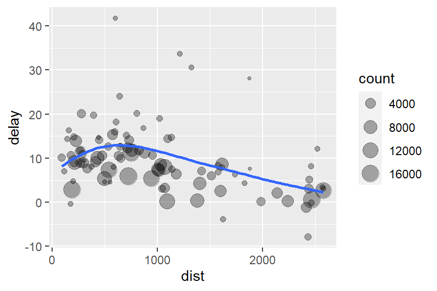

```r
ggplot(data = delays, mapping = aes(x = dist, y = delay)) +
  geom_point(aes(size = count), alpha = 1/3) +
  geom_smooth(se = FALSE)
```

#### b. `na.rm =`: drop `NA`

```r
flights %>%
  group_by(year, month, day) %>%
  summarise(mean = mean(dep_delay))
```

```
## # A tibble: 365 x 4
## # Groups:   year, month [12]
##     year month   day  mean
##    <int> <int> <int> <dbl>
##  1  2013     1     1    NA
##  2  2013     1     2    NA
##  3  2013     1     3    NA
##  4  2013     1     4    NA
##  5  2013     1     5    NA
##  6  2013     1     6    NA
##  7  2013     1     7    NA
##  8  2013     1     8    NA
##  9  2013     1     9    NA
## 10  2013     1    10    NA
## # ... with 355 more rows
```

```r
flights %>%
  group_by(year, month, day) %>%
  summarise(mean = mean(dep_delay, na.rm = TRUE))
```

```
## # A tibble: 365 x 4
## # Groups:   year, month [12]
##     year month   day  mean
##    <int> <int> <int> <dbl>
##  1  2013     1     1 11.5
##  2  2013     1     2 13.9
##  3  2013     1     3 11.0
##  4  2013     1     4  8.95
##  5  2013     1     5  5.73
##  6  2013     1     6  7.15
##  7  2013     1     7  5.42
##  8  2013     1     8  2.55
##  9  2013     1     9  2.28
## 10  2013     1    10  2.84
## # ... with 355 more rows
```

Remove canceled flights (`arr_delay` = `NA`)

```r
not_cancelled <- flights %>%
  filter(!is.na(dep_delay), !is.na(arr_delay))

not_cancelled %>%
  group_by(year, month, day) %>%
  summarise(mean = mean(dep_delay))
```

```
## # A tibble: 365 x 4
## # Groups:   year, month [12]
##     year month   day  mean
##    <int> <int> <int> <dbl>
##  1  2013     1     1 11.4
##  2  2013     1     2 13.7
##  3  2013     1     3 10.9
##  4  2013     1     4  8.97
##  5  2013     1     5  5.73
##  6  2013     1     6  7.15
##  7  2013     1     7  5.42
##  8  2013     1     8  2.56
##  9  2013     1     9  2.30
## 10  2013     1    10  2.84
## # ... with 355 more rows
```

#### c. count

**ex1: flight**  
(i) `ggplot2::geom_freqploy()`

```r
delays <- not_cancelled %>%
  group_by(tailnum) %>%
  summarise(
    delay = mean(arr_delay)
  )
```

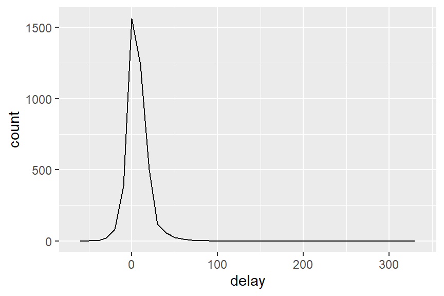

```r
ggplot(data = delays, mapping = aes(x = delay)) +
  geom_freqpoly(binwidth = 10)
```

2. `n()`: count

```r
delays <- not_cancelled %>%
  group_by(tailnum) %>%
  summarise(
    delay = mean(arr_delay),
    n = n()
  )
```

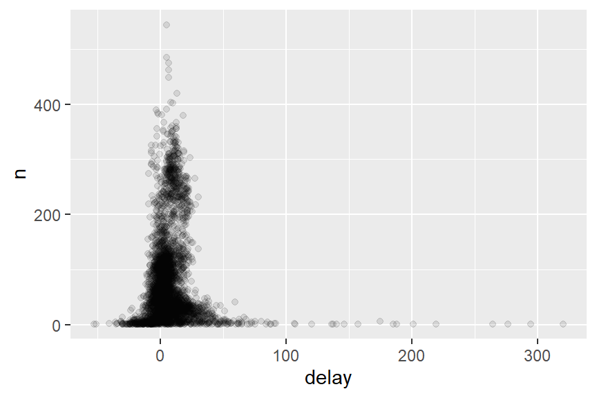

```r
ggplot(data = delays, mapping = aes(x = n, y = delay)) +
  geom_point(alpha = 1/10) +
  coord_flip()
```

3. `filter()`: `n > 25`

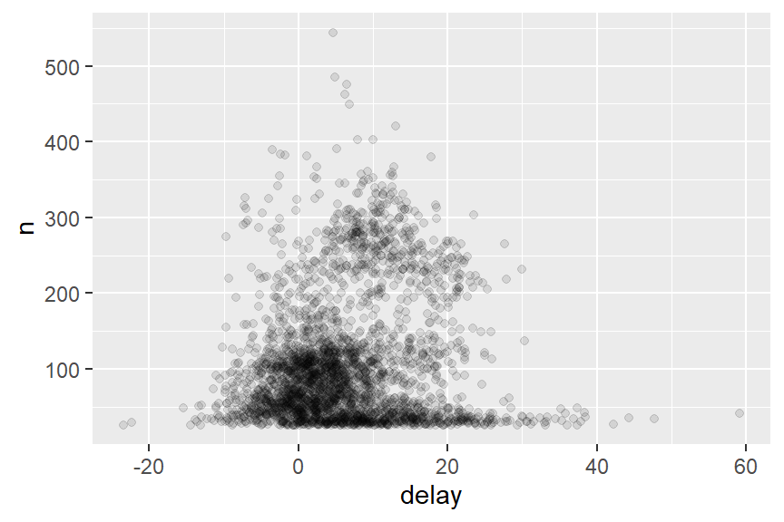

```r
delays %>%
  filter(n > 25) %>%
  ggplot(mapping = aes(x = n, y = delay)) +
    geom_point(alpha = 1/10) +
    coord_flip()
```

**ex2: batting**

```r
batting <- as_tibble(Lahman::Batting)

batters <- batting %>%
  group_by(playerID) %>%
  summarise(
    ba = sum(H, na.rm = TRUE) / sum(AB, na.rm = TRUE),
    ab = sum(AB, na.rm = TRUE)
  )
```

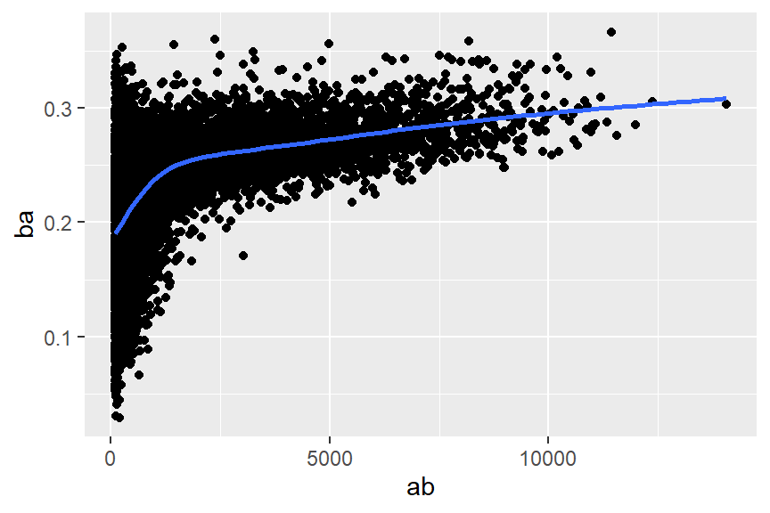

```r
batters %>%
  filter(ab > 100) %>%
  ggplot(mapping = aes(x = ab, y = ba)) +
    geom_point() +
    geom_smooth(se = FALSE)
```

```r
batters %>%
  arrange(desc(ba))
```

```
## # A tibble: 19,689 x 3
##    playerID     ba    ab
##    <chr>     <dbl> <int>
##  1 abramge01     1     1
##  2 alanirj01     1     1
##  3 alberan01     1     1
##  4 banisje01     1     1
##  5 bartocl01     1     1
##  6 bassdo01      1     1
##  7 birasst01     1     2
##  8 bruneju01     1     1
##  9 burnscb01     1     1
## 10 cammaer01     1     1
## # ... with 19,679 more rows
```

#### d. Summary functions

```r
not_cancelled %>%
  group_by(year, month, day) %>%
  summarise(
    avg_delay = mean(arr_delay),
    avg_delay_posi = mean(arr_delay[arr_delay > 0]) # the average positive delay
  )
```

```
## # A tibble: 365 x 5
## # Groups:   year, month [12]
##     year month   day avg_delay avg_delay_posi
##    <int> <int> <int>     <dbl>          <dbl>
##  1  2013     1     1    12.7             32.5
##  2  2013     1     2    12.7             32.0
##  3  2013     1     3     5.73            27.7
##  4  2013     1     4    -1.93            28.3
##  5  2013     1     5    -1.53            22.6
##  6  2013     1     6     4.24            24.4
##  7  2013     1     7    -4.95            27.8
##  8  2013     1     8    -3.23            20.8
##  9  2013     1     9    -0.264           25.6
## 10  2013     1    10    -5.90            27.3
## # ... with 355 more rows
```

- `min(x)`: minimum
- `quantile(x, 0.25)`: 25%
- `median(x)`: half
- `max(x)`: maximum
- `first(x)`: first
- `nth(x, N)`: Nth number
- `last(x)`: last
- `n()`: total number
- `sum(!is.na(x))`: total number excluding `NA`
- `n_distinct(chr)`: count distinct values *chr*
- `wt = X`: count a weighted value by *X*
- `sum(x > N)`: sum of x which are greater than *N*

## **`tibble`**

```r
library(tidyverse)
```

### Basic

#### Read a data frame as `tibble`

```r
as_tibble(iris)
```

```
## # A tibble: 150 x 5
##    Sepal.Length Sepal.Width Petal.Length Petal.Width Species
##           <dbl>       <dbl>        <dbl>       <dbl> <fct>
##  1          5.1         3.5          1.4         0.2 setosa
##  2          4.9         3            1.4         0.2 setosa
##  3          4.7         3.2          1.3         0.2 setosa
##  4          4.6         3.1          1.5         0.2 setosa
##  5          5           3.6          1.4         0.2 setosa
##  6          5.4         3.9          1.7         0.4 setosa
##  7          4.6         3.4          1.4         0.3 setosa
##  8          5           3.4          1.5         0.2 setosa
##  9          4.4         2.9          1.4         0.2 setosa
## 10          4.9         3.1          1.5         0.1 setosa
## # ... with 140 more rows
```

#### a. Create a **tibble** with `tibble()`

```r
tibble(
  x = 1:5,
  y = 1,
  z = x ^ 2 + y
)
```

```
## # A tibble: 5 x 3
##       x     y     z
##   <int> <dbl> <dbl>
## 1     1     1     2
## 2     2     1     5
## 3     3     1    10
## 4     4     1    17
## 5     5     1    26
```

#### b. Create a **tibble** with `tribble()`

```r
tb <- tribble(
  ~x, ~y, ~z,
  #--|--|----
  "a", 2, 3.6,
  "b", 1, 8.5
)
tb
```

```
## # A tibble: 2 x 3
##   x         y     z
##   <chr> <dbl> <dbl>
## 1 a         2   3.6
## 2 b         1   8.5
```

#### c. Convert **tibble** to **data.frame**

```r
df <- as.data.frame(tb)
class(tb)
```

```
## [1] "tbl_df"     "tbl"        "data.frame"
```

```r
class(df)
```

```
## [1] "data.frame"
```

### Tibble vs data.frame

#### a. Printing

```r
tibble(
  a = lubridate::now() + runif(1e3) * 86316,
  b = lubridate::today() + runif(1e3) * 30,
  c = 1:1e3,
  d = runif(1e3),
  e = sample(letters, 1e3, replace = TRUE)
)
```

```
## # A tibble: 1,000 x 5
##    a                   b              c      d e
##    <dttm>              <date>     <int>  <dbl> <chr>
##  1 2020-07-10 01:10:28 2020-07-22     1 0.944  a
##  2 2020-07-09 21:06:13 2020-07-26     2 0.244  z
##  3 2020-07-10 01:40:29 2020-08-05     3 0.253  o
##  4 2020-07-10 04:53:31 2020-07-21     4 0.185  g
##  5 2020-07-09 18:08:12 2020-07-12     5 0.314  u
##  6 2020-07-10 16:07:23 2020-07-29     6 0.0186 q
##  7 2020-07-10 05:31:50 2020-07-11     7 0.538  i
##  8 2020-07-09 23:41:48 2020-07-20     8 0.103  x
##  9 2020-07-10 07:37:19 2020-08-06     9 0.411  f
## 10 2020-07-10 04:42:10 2020-07-14    10 0.539  h
## # ... with 990 more rows
```

#### b. Subsetting

```r
tb <- tibble(
  x = runif(5),
  y = rnorm(5)
)
tb

# xtract by name
tb$x
tb[["x"]]

# Extract by position
tb[[1]]

# Extract with a pipe
tb %>% .$x
tb %>% .[["x"]]
tb %>% .[[1]]
```

```
## # A tibble: 5 x 2
##       x       y
##   <dbl>   <dbl>
## 1 0.977  0.701
## 2 0.426  0.793
## 3 0.777 -0.0242
## 4 0.341  1.61
## 5 0.595  1.24
## [1] 0.9773 0.4256 0.7765 0.3409 0.5950
## [1] 0.9773 0.4256 0.7765 0.3409 0.5950
## [1] 0.9773 0.4256 0.7765 0.3409 0.5950
## [1] 0.9773 0.4256 0.7765 0.3409 0.5950
## [1] 0.9773 0.4256 0.7765 0.3409 0.5950
## [1] 0.9773 0.4256 0.7765 0.3409 0.5950
```

## **`tidyr`**

### Basic

```r
library(tidyverse)
table1
table2
table3
```

```
## # A tibble: 6 x 4
##   country      year  cases population
##   <chr>       <int>  <int>      <int>
## 1 Afghanistan  1999    745   19987071
## 2 Afghanistan  2000   2666   20595360
## 3 Brazil       1999  37737  172006362
## 4 Brazil       2000  80488  174504898
## 5 China        1999 212258 1272915272
## 6 China        2000 213766 1280428583
## # A tibble: 12 x 4
##    country      year type            count
##    <chr>       <int> <chr>           <int>
##  1 Afghanistan  1999 cases             745
##  2 Afghanistan  1999 population   19987071
##  3 Afghanistan  2000 cases            2666
```

[output cut: 18 more lines]

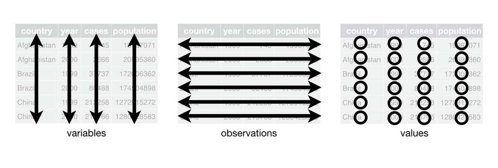

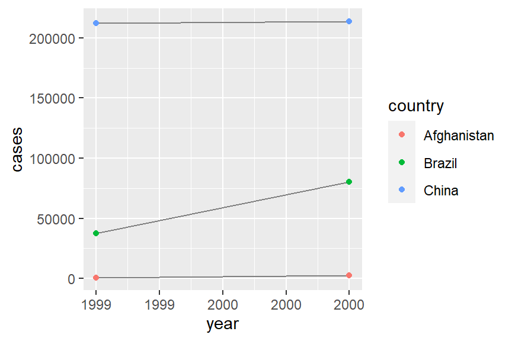

```
## # A tibble: 6 x 5
##   country      year  cases population  rate
##   <chr>       <int>  <int>      <int> <dbl>
## 1 Afghanistan  1999    745   19987071 0.373
## 2 Afghanistan  2000   2666   20595360 1.29
## 3 Brazil       1999  37737  172006362 2.19
## 4 Brazil       2000  80488  174504898 4.61
## 5 China        1999 212258 1272915272 1.67
## 6 China        2000 213766 1280428583 1.67
## # A tibble: 2 x 2
##    year      n
##   <int>  <int>
## 1  1999 250740
## 2  2000 296920
```

```r
# Compute rate per 10,000
table1 %>%
  mutate(rate = cases / population * 10000)

# Compute cases per year
table1 %>%
  count(year, wt = cases)

# Visualize changes over time
library(ggplot2)
ggplot(table1, aes(year, cases)) +
  geom_line(aes(group = country), colour = "grey50") +
  geom_point(aes(colour = country))
```

### Pivot

#### (i) `pivot_longer()`

e.g. `year` is **variable**, not **observation**

```r
table4a
table4b
```

```
## # A tibble: 3 x 3
##   country     `1999` `2000`
## * <chr>        <int>  <int>
## 1 Afghanistan    745   2666
## 2 Brazil       37737  80488
## 3 China       212258 213766
## # A tibble: 3 x 3
##   country         `1999`     `2000`
## * <chr>            <int>      <int>
## 1 Afghanistan   19987071   20595360
## 2 Brazil       172006362  174504898
## 3 China       1272915272 1280428583
```

**Make longer table4a**

```r
table4a %>%
  pivot_longer(c("1999", "2000"), names_to = "year", values_to = "cases")
```

```
## # A tibble: 6 x 3
##   country     year   cases
##   <chr>       <chr>  <int>
## 1 Afghanistan 1999     745
## 2 Afghanistan 2000    2666
## 3 Brazil      1999   37737
## 4 Brazil      2000   80488
## 5 China       1999  212258
## 6 China       2000  213766
```

**Make longer table4b**

```r
table4b %>%
  pivot_longer(c("1999", "2000"), names_to = "year", values_to = "population")
```

```
## # A tibble: 6 x 3
##   country     year  population
##   <chr>       <chr>      <int>
## 1 Afghanistan 1999    19987071
## 2 Afghanistan 2000    20595360
## 3 Brazil      1999   172006362
## 4 Brazil      2000   174504898
## 5 China       1999  1272915272
## 6 China       2000  1280428583
```

**Join table4a and table4b**

```r
tidy4a <- table4a %>%
  pivot_longer(c("1999", "2000"), names_to = "year", values_to = "cases")
tidy4b <- table4b %>%
  pivot_longer(c("1999", "2000"), names_to = "year", values_to = "population")
left_join(tidy4a, tidy4b)
```

```
## # A tibble: 6 x 4
##   country     year   cases population
##   <chr>       <chr>  <int>      <int>
## 1 Afghanistan 1999     745   19987071
## 2 Afghanistan 2000    2666   20595360
## 3 Brazil      1999   37737  172006362
## 4 Brazil      2000   80488  174504898
## 5 China       1999  212258 1272915272
## 6 China       2000  213766 1280428583
```

#### (ii) `pivot_wider()`

e.g. `type` is **observation**, not **variable**

```r
table2
```

```
## # A tibble: 12 x 4
##    country      year type            count
##    <chr>       <int> <chr>           <int>
##  1 Afghanistan  1999 cases             745
##  2 Afghanistan  1999 population   19987071
##  3 Afghanistan  2000 cases            2666
##  4 Afghanistan  2000 population   20595360
##  5 Brazil       1999 cases           37737
##  6 Brazil       1999 population  172006362
##  7 Brazil       2000 cases           80488
##  8 Brazil       2000 population  174504898
##  9 China        1999 cases          212258
## 10 China        1999 population 1272915272
## 11 China        2000 cases          213766
## 12 China        2000 population 1280428583
```

**Wider table2**

```r
table2 %>%
    pivot_wider(names_from = type, values_from = count)
```

```
## # A tibble: 6 x 4
##   country      year  cases population
##   <chr>       <int>  <int>      <int>
## 1 Afghanistan  1999    745   19987071
## 2 Afghanistan  2000   2666   20595360
## 3 Brazil       1999  37737  172006362
## 4 Brazil       2000  80488  174504898
## 5 China        1999 212258 1272915272
## 6 China        2000 213766 1280428583
```

### separate and unite

#### (i) `separate()`

e.g. `rate` has two variables

```r
table3
```

```
## # A tibble: 6 x 3
##   country      year rate
## * <chr>       <int> <chr>
## 1 Afghanistan  1999 745/19987071
## 2 Afghanistan  2000 2666/20595360
## 3 Brazil       1999 37737/172006362
## 4 Brazil       2000 80488/174504898
## 5 China        1999 212258/1272915272
## 6 China        2000 213766/1280428583
```

```r
table3 %>%
  separate(rate, into = c("cases", "population"), sep = "/", convert = TRUE)

table3 %>%
  separate(year, into = c("century", "year"), sep = 2, convert = TRUE)
```

```
## # A tibble: 6 x 4
##   country      year  cases population
##   <chr>       <int>  <int>      <int>
## 1 Afghanistan  1999    745   19987071
## 2 Afghanistan  2000   2666   20595360
## 3 Brazil       1999  37737  172006362
## 4 Brazil       2000  80488  174504898
## 5 China        1999 212258 1272915272
## 6 China        2000 213766 1280428583
## # A tibble: 6 x 4
##   country     century  year rate
##   <chr>         <int> <int> <chr>
## 1 Afghanistan      19    99 745/19987071
## 2 Afghanistan      20     0 2666/20595360
## 3 Brazil           19    99 37737/172006362
## 4 Brazil           20     0 80488/174504898
## 5 China            19    99 212258/1272915272
## 6 China            20     0 213766/1280428583
```

- `sep =`: specify the place to separate
- `convert =`: if TRUE, try and convert to better types

#### (ii) `unite()`

e.g. `century` and `year` can be united

```r
table5
```

```
## # A tibble: 6 x 4
##   country     century year  rate
## * <chr>       <chr>   <chr> <chr>
## 1 Afghanistan 19      99    745/19987071
## 2 Afghanistan 20      00    2666/20595360
## 3 Brazil      19      99    37737/172006362
## 4 Brazil      20      00    80488/174504898
## 5 China       19      99    212258/1272915272
## 6 China       20      00    213766/1280428583
```

```r
table5 %>%
  unite(new, century, year, sep = "")
```

```
## # A tibble: 6 x 3
##   country     new   rate
##   <chr>       <chr> <chr>
## 1 Afghanistan 1999  745/19987071
## 2 Afghanistan 2000  2666/20595360
## 3 Brazil      1999  37737/172006362
## 4 Brazil      2000  80488/174504898
## 5 China       1999  212258/1272915272
## 6 China       2000  213766/1280428583
```

### Missing values

two types of missing values

- **explicitly**: i.e. flagged with `NA` (the presence of an absence)
- **implicitly**: i.e. simply not present in the data (the absence of a presence)

```r
stocks <- tibble(
  year   = c(2015, 2015, 2015, 2015, 2016, 2016, 2016),
  qtr    = c(   1,    2,    3,    4,    2,    3,    4),
  return = c(1.88, 0.59, 0.35,   NA, 0.92, 0.17, 2.66)
)

stocks %>%
  pivot_wider(names_from = year, values_from = return)
```

```
## # A tibble: 4 x 3
##     qtr `2015` `2016`
##   <dbl>  <dbl>  <dbl>
## 1     1   1.88  NA
## 2     2   0.59   0.92
## 3     3   0.35   0.17
## 4     4  NA      2.66
```

#### (i) longer with `value_drop_na`

```r
stocks %>%
  pivot_wider(names_from = year, values_from = return) %>%
  pivot_longer(
    cols = c(`2015`, `2016`),
    names_to = "year",
    values_to = "return",
    values_drop_na = TRUE
  )
```

```
## # A tibble: 6 x 3
##     qtr year  return
##   <dbl> <chr>  <dbl>
## 1     1 2015    1.88
## 2     2 2015    0.59
## 3     2 2016    0.92
## 4     3 2015    0.35
## 5     3 2016    0.17
## 6     4 2016    2.66
```

- `values_drop_na =`: if TRUE, `NA` is dropped

#### (ii) `complete()`

```r
stocks %>%
  complete(year, qtr)
```

```
## # A tibble: 8 x 3
##    year   qtr return
##   <dbl> <dbl>  <dbl>
## 1  2015     1   1.88
## 2  2015     2   0.59
## 3  2015     3   0.35
## 4  2015     4  NA
## 5  2016     1  NA
## 6  2016     2   0.92
## 7  2016     3   0.17
## 8  2016     4   2.66
```

#### (iii)`fill()` to replace NA by the most recent non-missing value

```r
treatment <- tribble(
  ~ person,           ~ treatment, ~response,
  "Derrick Whitmore", 1,           7,
  NA,                 2,           10,
  NA,                 3,           9,
  "Katherine Burke",  1,           4
)

treatment %>%
  fill(person)
```

```
## # A tibble: 4 x 3
##   person           treatment response
##   <chr>                <dbl>    <dbl>
## 1 Derrick Whitmore         1        7
## 2 Derrick Whitmore         2       10
## 3 Derrick Whitmore         3        9
## 4 Katherine Burke          1        4
```

### Case study (using WHO data)

```r
who
```

```
## # A tibble: 7,240 x 60
##    country iso2  iso3   year new_sp_m014 new_sp_m1524 new_sp_m2534 new_sp_m3544 new_sp_m4554 new_sp_m5564 new_sp_m65 new_sp_f014 new_sp_f1524
##    <chr>   <chr> <chr> <int>       <int>        <int>        <int>        <int>        <int>        <int>      <int>       <int>        <int>
##  1 Afghan~ AF    AFG    1980          NA           NA           NA           NA           NA           NA         NA          NA           NA
##  2 Afghan~ AF    AFG    1981          NA           NA           NA           NA           NA           NA         NA          NA           NA
##  3 Afghan~ AF    AFG    1982          NA           NA           NA           NA           NA           NA         NA          NA           NA
##  4 Afghan~ AF    AFG    1983          NA           NA           NA           NA           NA           NA         NA          NA           NA
##  5 Afghan~ AF    AFG    1984          NA           NA           NA           NA           NA           NA         NA          NA           NA
##  6 Afghan~ AF    AFG    1985          NA           NA           NA           NA           NA           NA         NA          NA           NA
##  7 Afghan~ AF    AFG    1986          NA           NA           NA           NA           NA           NA         NA          NA           NA
##  8 Afghan~ AF    AFG    1987          NA           NA           NA           NA           NA           NA         NA          NA           NA
##  9 Afghan~ AF    AFG    1988          NA           NA           NA           NA           NA           NA         NA          NA           NA
## 10 Afghan~ AF    AFG    1989          NA           NA           NA           NA           NA           NA         NA          NA           NA
## # ... with 7,230 more rows, and 47 more variables: new_sp_f2534 <int>, new_sp_f3544 <int>, new_sp_f4554 <int>, new_sp_f5564 <int>, new_sp_f65 <int>,
## #   new_sn_m014 <int>, new_sn_m1524 <int>, new_sn_m2534 <int>, new_sn_m3544 <int>, new_sn_m4554 <int>, new_sn_m5564 <int>, new_sn_m65 <int>,
## #   new_sn_f014 <int>, new_sn_f1524 <int>, new_sn_f2534 <int>, new_sn_f3544 <int>, new_sn_f4554 <int>, new_sn_f5564 <int>, new_sn_f65 <int>,
## #   new_ep_m014 <int>, new_ep_m1524 <int>, new_ep_m2534 <int>, new_ep_m3544 <int>, new_ep_m4554 <int>, new_ep_m5564 <int>, new_ep_m65 <int>,
## #   new_ep_f014 <int>, new_ep_f1524 <int>, new_ep_f2534 <int>, new_ep_f3544 <int>, new_ep_f4554 <int>, new_ep_f5564 <int>, new_ep_f65 <int>,
## #   newrel_m014 <int>, newrel_m1524 <int>, newrel_m2534 <int>, newrel_m3544 <int>, newrel_m4554 <int>, newrel_m5564 <int>, newrel_m65 <int>,
## #   newrel_f014 <int>, newrel_f1524 <int>, newrel_f2534 <int>, newrel_f3544 <int>, newrel_f4554 <int>, newrel_f5564 <int>, newrel_f65 <int>
```

#### a. `pivot_longer()`

```r
who1 <- who %>%
  pivot_longer(
    new_sp_m014:newrel_f65,
    names_to = "key",
    values_to = "cases",
    values_drop_na = TRUE
  )
who1
```

```
## # A tibble: 76,046 x 6
##    country     iso2  iso3   year key          cases
##    <chr>       <chr> <chr> <int> <chr>        <int>
##  1 Afghanistan AF    AFG    1997 new_sp_m014      0
##  2 Afghanistan AF    AFG    1997 new_sp_m1524    10
##  3 Afghanistan AF    AFG    1997 new_sp_m2534     6
##  4 Afghanistan AF    AFG    1997 new_sp_m3544     3
##  5 Afghanistan AF    AFG    1997 new_sp_m4554     5
##  6 Afghanistan AF    AFG    1997 new_sp_m5564     2
##  7 Afghanistan AF    AFG    1997 new_sp_m65       0
##  8 Afghanistan AF    AFG    1997 new_sp_f014      5
##  9 Afghanistan AF    AFG    1997 new_sp_f1524    38
## 10 Afghanistan AF    AFG    1997 new_sp_f2534    36
## # ... with 76,036 more rows
```

#### b. `count()`: count the number of each ovservation

```r
who1 %>%
  count(key)
```

```
## # A tibble: 56 x 2
##    key              n
##    <chr>        <int>
##  1 new_ep_f014   1032
##  2 new_ep_f1524  1021
##  3 new_ep_f2534  1021
##  4 new_ep_f3544  1021
##  5 new_ep_f4554  1017
##  6 new_ep_f5564  1017
##  7 new_ep_f65    1014
##  8 new_ep_m014   1038
##  9 new_ep_m1524  1026
## 10 new_ep_m2534  1020
## # ... with 46 more rows
```

#### c. tidy **key** colunm

- `mutate()`: **newrel** -> **new** and **rel**
- `separate()`: **key** -> **type**, **sex_age**
- `separate()`: **sex_age** -> **sex**, **age**
- `select()`: drop some variables (**new**, **iso2**, **iso3**)
1. `mutate()`: **newrel** -> **new** and **rel**

```r
who2 <- who1 %>%
  mutate(names_from = stringr::str_replace(key, "newrel", "new_rel"))
who2
```

```
## # A tibble: 76,046 x 7
##    country     iso2  iso3   year key          cases names_from
##    <chr>       <chr> <chr> <int> <chr>        <int> <chr>
##  1 Afghanistan AF    AFG    1997 new_sp_m014      0 new_sp_m014
##  2 Afghanistan AF    AFG    1997 new_sp_m1524    10 new_sp_m1524
##  3 Afghanistan AF    AFG    1997 new_sp_m2534     6 new_sp_m2534
##  4 Afghanistan AF    AFG    1997 new_sp_m3544     3 new_sp_m3544
##  5 Afghanistan AF    AFG    1997 new_sp_m4554     5 new_sp_m4554
##  6 Afghanistan AF    AFG    1997 new_sp_m5564     2 new_sp_m5564
##  7 Afghanistan AF    AFG    1997 new_sp_m65       0 new_sp_m65
##  8 Afghanistan AF    AFG    1997 new_sp_f014      5 new_sp_f014
##  9 Afghanistan AF    AFG    1997 new_sp_f1524    38 new_sp_f1524
## 10 Afghanistan AF    AFG    1997 new_sp_f2534    36 new_sp_f2534
## # ... with 76,036 more rows
```

2. `separate()`: **key** -> **type**, **sex_age**

```r
who3 <- who2 %>%
  separate(key, c("new", "type", "sexage"), sep = "_")
who3
```

```
## # A tibble: 76,046 x 9
##    country     iso2  iso3   year new   type  sexage cases names_from
##    <chr>       <chr> <chr> <int> <chr> <chr> <chr>  <int> <chr>
##  1 Afghanistan AF    AFG    1997 new   sp    m014       0 new_sp_m014
##  2 Afghanistan AF    AFG    1997 new   sp    m1524     10 new_sp_m1524
##  3 Afghanistan AF    AFG    1997 new   sp    m2534      6 new_sp_m2534
##  4 Afghanistan AF    AFG    1997 new   sp    m3544      3 new_sp_m3544
##  5 Afghanistan AF    AFG    1997 new   sp    m4554      5 new_sp_m4554
##  6 Afghanistan AF    AFG    1997 new   sp    m5564      2 new_sp_m5564
##  7 Afghanistan AF    AFG    1997 new   sp    m65        0 new_sp_m65
##  8 Afghanistan AF    AFG    1997 new   sp    f014       5 new_sp_f014
##  9 Afghanistan AF    AFG    1997 new   sp    f1524     38 new_sp_f1524
## 10 Afghanistan AF    AFG    1997 new   sp    f2534     36 new_sp_f2534
## # ... with 76,036 more rows
```

3. `separate()`: **sex_age** -> **sex**, **age**

```r
who4 <- who3 %>%
  separate(sexage, c("sex", "age"), sep = 1)
who4
```

```
## # A tibble: 76,046 x 10
##    country     iso2  iso3   year new   type  sex   age   cases names_from
##    <chr>       <chr> <chr> <int> <chr> <chr> <chr> <chr> <int> <chr>
##  1 Afghanistan AF    AFG    1997 new   sp    m     014       0 new_sp_m014
##  2 Afghanistan AF    AFG    1997 new   sp    m     1524     10 new_sp_m1524
##  3 Afghanistan AF    AFG    1997 new   sp    m     2534      6 new_sp_m2534
##  4 Afghanistan AF    AFG    1997 new   sp    m     3544      3 new_sp_m3544
##  5 Afghanistan AF    AFG    1997 new   sp    m     4554      5 new_sp_m4554
##  6 Afghanistan AF    AFG    1997 new   sp    m     5564      2 new_sp_m5564
##  7 Afghanistan AF    AFG    1997 new   sp    m     65        0 new_sp_m65
##  8 Afghanistan AF    AFG    1997 new   sp    f     014       5 new_sp_f014
##  9 Afghanistan AF    AFG    1997 new   sp    f     1524     38 new_sp_f1524
## 10 Afghanistan AF    AFG    1997 new   sp    f     2534     36 new_sp_f2534
## # ... with 76,036 more rows
```

4. `select()`: drop **new**, **iso2**, and **iso3**

```r
who5  <- who4 %>%
  select(-new, -iso2, -iso3)
who5
```

```
## # A tibble: 76,046 x 7
##    country      year type  sex   age   cases names_from
##    <chr>       <int> <chr> <chr> <chr> <int> <chr>
##  1 Afghanistan  1997 sp    m     014       0 new_sp_m014
##  2 Afghanistan  1997 sp    m     1524     10 new_sp_m1524
##  3 Afghanistan  1997 sp    m     2534      6 new_sp_m2534
##  4 Afghanistan  1997 sp    m     3544      3 new_sp_m3544
##  5 Afghanistan  1997 sp    m     4554      5 new_sp_m4554
##  6 Afghanistan  1997 sp    m     5564      2 new_sp_m5564
##  7 Afghanistan  1997 sp    m     65        0 new_sp_m65
##  8 Afghanistan  1997 sp    f     014       5 new_sp_f014
##  9 Afghanistan  1997 sp    f     1524     38 new_sp_f1524
## 10 Afghanistan  1997 sp    f     2534     36 new_sp_f2534
## # ... with 76,036 more rows
```

#### d. with one code

```r
who %>%
  pivot_longer(
    cols = new_sp_m014:newrel_f65,
    names_to = "key",
    values_to = "cases",
    values_drop_na = TRUE
  ) %>%
  mutate(
    key = stringr::str_replace(key, "newrel", "new_rel")
  ) %>%
  separate(key, c("new", "var", "sexage")) %>%
  separate(sexage, c("sex", "age"), sep = 1) %>%
  select(-new, -iso2, -iso3)
```

```
## # A tibble: 76,046 x 6
##    country      year var   sex   age   cases
##    <chr>       <int> <chr> <chr> <chr> <int>
##  1 Afghanistan  1997 sp    m     014       0
##  2 Afghanistan  1997 sp    m     1524     10
##  3 Afghanistan  1997 sp    m     2534      6
##  4 Afghanistan  1997 sp    m     3544      3
##  5 Afghanistan  1997 sp    m     4554      5
##  6 Afghanistan  1997 sp    m     5564      2
##  7 Afghanistan  1997 sp    m     65        0
##  8 Afghanistan  1997 sp    f     014       5
##  9 Afghanistan  1997 sp    f     1524     38
## 10 Afghanistan  1997 sp    f     2534     36
## # ... with 76,036 more rows
```

## Relational Data

```r
library(tidyverse)
library(nycflights13)
```

**mutating joins**: add new variables to a data frame from matching observations in another.  
**filtering joins**: filter observations from a data frame based on whether they match an observation in the other table  
**set operations**: treat observations as if they were set elements

#### five dataset

```r
flights
airlines
airports
planes
weather
```

```
## # A tibble: 336,776 x 19
##     year month   day dep_time sched_dep_time dep_delay arr_time sched_arr_time arr_delay carrier flight tailnum origin dest  air_time distance  hour
##    <int> <int> <int>    <int>          <int>     <dbl>    <int>          <int>     <dbl> <chr>    <int> <chr>   <chr>  <chr>    <dbl>    <dbl> <dbl>
##  1  2013     1     1      517            515         2      830            819        11 UA        1545 N14228  EWR    IAH        227     1400     5
##  2  2013     1     1      533            529         4      850            830        20 UA        1714 N24211  LGA    IAH        227     1416     5
##  3  2013     1     1      542            540         2      923            850        33 AA        1141 N619AA  JFK    MIA        160     1089     5
##  4  2013     1     1      544            545        -1     1004           1022       -18 B6         725 N804JB  JFK    BQN        183     1576     5
##  5  2013     1     1      554            600        -6      812            837       -25 DL         461 N668DN  LGA    ATL        116      762     6
##  6  2013     1     1      554            558        -4      740            728        12 UA        1696 N39463  EWR    ORD        150      719     5
##  7  2013     1     1      555            600        -5      913            854        19 B6         507 N516JB  EWR    FLL        158     1065     6
##  8  2013     1     1      557            600        -3      709            723       -14 EV        5708 N829AS  LGA    IAD         53      229     6
##  9  2013     1     1      557            600        -3      838            846        -8 B6          79 N593JB  JFK    MCO        140      944     6
## 10  2013     1     1      558            600        -2      753            745         8 AA         301 N3ALAA  LGA    ORD        138      733     6
## # ... with 336,766 more rows, and 2 more variables: minute <dbl>, time_hour <dttm>
## # A tibble: 16 x 2
```

[output cut: 60 more lines]

### Keys

```r
planes %>%
  count(tailnum) %>%
  filter(n > 1)
```

```
## # A tibble: 0 x 2
## # ... with 2 variables: tailnum <chr>, n <int>
```

```r
weather %>%
  count(year, month, day, hour, origin) %>%
  filter(n > 1)
```

```
## # A tibble: 3 x 6
##    year month   day  hour origin     n
##   <int> <int> <int> <int> <chr>  <int>
## 1  2013    11     3     1 EWR        2
## 2  2013    11     3     1 JFK        2
## 3  2013    11     3     1 LGA        2
```

### (i) Mutating joins

**basic**  
- `inner_join(x, y, by = "key")`  
- `left_join(x, y, by = "key")`  
- `right_join(x, y, by = "key")`  
- `full_join(x, y, by = "key")`  
**define keys**  
- `by = "key"`  
- `by = c("key_x" = "key_y")`

#### a. inner and outer join

```r
x <- tribble(
  ~key, ~val_x,
     1, "x1",
     2, "x2",
     3, "x3"
)
y <- tribble(
  ~key, ~val_y,
     1, "y1",
     2, "y2",
     4, "y3"
)
```

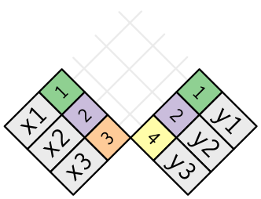

```r
x %>%
  inner_join(y, by = "key")

x %>%
  left_join(y, by = "key")

x %>%
  right_join(y, by = "key")

x %>%
  full_join(y, by = "key")
```

```
## # A tibble: 2 x 3
##     key val_x val_y
##   <dbl> <chr> <chr>
## 1     1 x1    y1
## 2     2 x2    y2
## # A tibble: 3 x 3
##     key val_x val_y
##   <dbl> <chr> <chr>
## 1     1 x1    y1
## 2     2 x2    y2
## 3     3 x3    <NA>
## # A tibble: 3 x 3
##     key val_x val_y
##   <dbl> <chr> <chr>
## 1     1 x1    y1
## 2     2 x2    y2
## 3     4 <NA>  y3
## # A tibble: 4 x 3
##     key val_x val_y
##   <dbl> <chr> <chr>
## 1     1 x1    y1
## 2     2 x2    y2
## 3     3 x3    <NA>
## 4     4 <NA>  y3
```


#### b. duplicate keys

**one-side**

```r
x <- tribble(
  ~key_x, ~val_x,
     1, "x1",
     2, "x2",
     2, "x3",
     1, "x4"
)
y <- tribble(
  ~key_y, ~val_y,
     1, "y1",
     2, "y2"
)

left_join(x, y, by = c("key_x" = "key_y"))
```

```
## # A tibble: 4 x 3
##   key_x val_x val_y
##   <dbl> <chr> <chr>
## 1     1 x1    y1
## 2     2 x2    y2
## 3     2 x3    y2
## 4     1 x4    y1
```

**both-side**

```r
x <- tribble(
  ~key_x, ~val_x,
     1, "x1",
     2, "x2",
     2, "x3",
     3, "x4"
)
y <- tribble(
  ~key_y, ~val_y,
     1, "y1",
     2, "y2",
     2, "y3",
     3, "y4"
)

left_join(x, y, by = c("key_x" = "key_y"))
```

```
## # A tibble: 6 x 3
##   key_x val_x val_y
##   <dbl> <chr> <chr>
## 1     1 x1    y1
## 2     2 x2    y2
## 3     2 x2    y3
## 4     2 x3    y2
## 5     2 x3    y3
## 6     3 x4    y4
```

### (ii) Filtering joins

- `semi_join(x, y)`: keeps all observations in x that have a match in y
- `anti_join(x, y)`: drops all observations in x that have a match in y (check if *foreign* keys match *primary* keys)

```r
x <- tribble(
  ~key, ~val_x,
     1, "x1",
     2, "x2",
     3, "x3"
)
y <- tribble(
  ~key, ~val_y,
     1, "y1",
     2, "y2",
     4, "y3"
)

x %>%
  semi_join(y, by = "key")

x %>%
  anti_join(y, by = "key")
```

```
## # A tibble: 2 x 2
##     key val_x
##   <dbl> <chr>
## 1     1 x1
## 2     2 x2
## # A tibble: 1 x 2
##     key val_x
##   <dbl> <chr>
## 1     3 x3
```

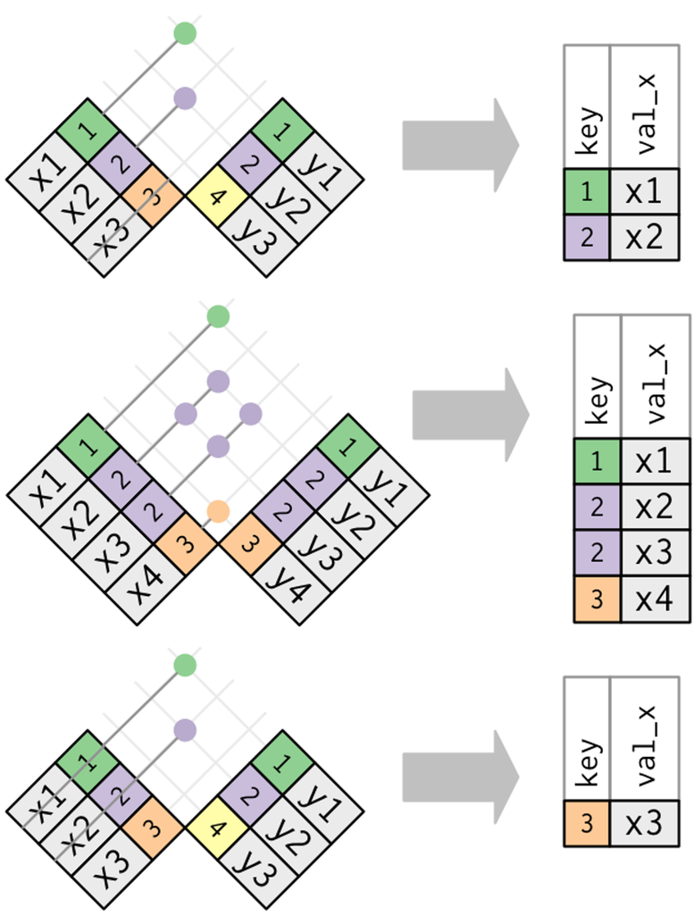

### (iii) Set operations

- `intersect(x, y)`: return only observations in both `x` and `y`
- `union(x, y)`: return unique observations in `x` and `y`
- `setdiff(x, y)`: return observations in `x`, but not in `y`

#### dataset

```r
df1 <- tribble(
  ~x, ~y,
   1,  1,
   2,  1
)

df2 <- tribble(
  ~x, ~y,
   1,  1,
   1,  2
)
```

#### a. `intersect()`

```r
intersect(df1, df2)
```

```
## # A tibble: 1 x 2
##       x     y
##   <dbl> <dbl>
## 1     1     1
```

#### b. `union()`

```r
union(df1, df2)
```

```
## # A tibble: 3 x 2
##       x     y
##   <dbl> <dbl>
## 1     1     1
## 2     2     1
## 3     1     2
```

#### c. `setdiff()`

```r
setdiff(df1, df2)
```

```
## # A tibble: 1 x 2
##       x     y
##   <dbl> <dbl>
## 1     2     1
```

```r
setdiff(df2, df1)
```

```
## # A tibble: 1 x 2
##       x     y
##   <dbl> <dbl>
## 1     1     2
```